# ME613 - Análise de Regressão

## Regressão Linear Múltipla

## Regressão Linear Múltipla

Imagine que algum pesquisador apresente o seguinte resultado: há relação entre uso de balinhas de menta (\(X\), total por dia) e função pulmonar (\(Y\), FEV).

O que você diria?

Você poderia argumentar, por exemplo, que fumantes consomem mais balinhas de menta e que o fato de ser fumante influencia na função pulmonar, não as balinhas.

O pesquisador então perguntaria: como eu poderia convencer você do efeito das balinhas?

## Regressão Linear Múltipla

Ou seja, para verificar o efeito do consumo de balinhas de menta, você gostaria de manter o efeito do cigarro (fumantes e não fumante) fixo.

A técnica de regressão linear múltipla pode ser usada neste caso: ela avaliará a relação entre um preditor e a resposta, enquanto "controla" pelas demais variáveis no modelo.

## Modelo com duas variáveis preditoras

\[Y_i=\beta_0+\beta_1X_{i1}+\beta_2 X_{i2}+\varepsilon_i\]

\(X_{i1}\) e \(X_{i2}\) são valores de duas variáveis preditoras para a observação \(i\).

Assumindo que \(E(\varepsilon_i)=0\,,\forall i\):

\[E(Y)=\beta_0+\beta_1X_{1}+\beta_2 X_{2}\]

## Exemplo

Na situação com duas variáveis preditoras, a função de regressão representa um plano:

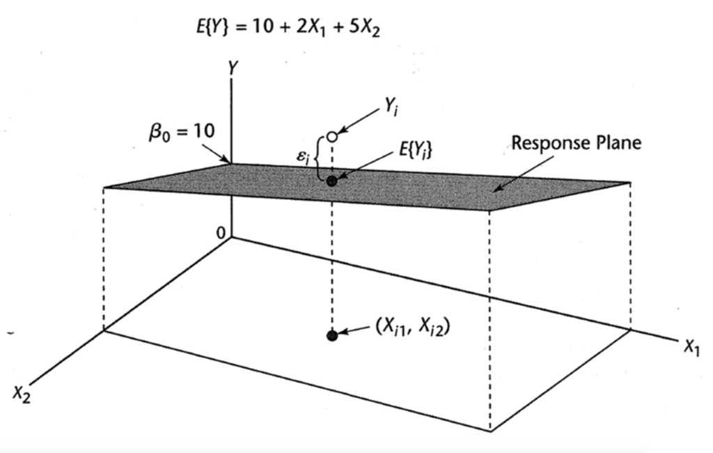

## Exemplo

Interpretação dos coeficientes:

- \(\beta_0\) (intercepto): valor esperado de \(Y\) quando \(X_1=0\) e \(X_2=0\).
- \(\beta_1\): indica a mudança no valor esperado de \(Y\) para cada unidade de aumento de \(X_1\), quando \(X_2\) é mantida constante.
- \(\beta_2\): indica a mudança no valor esperado de \(Y\) para cada unidade de aumento de \(X_2\), quando \(X_1\) é mantida constante.

Exemplo, se fixamos \(X_2=2\):

\[E(Y)=10+2X_1+5\times 2=20+2X_1\]

## Exemplo

- Se \(\beta_1=2\): o valor esperado de \(Y\) aumenta 2 unidades a cada aumento de 1 unidade de \(X_1\) e \(X_2\) mantida constante.
- Se \(\beta_2=5\): o valor esperado de \(Y\) aumenta 5 unidades a cada aumento de 1 unidade de \(X_2\) e \(X_1\) mantida constante.

## Exemplo

Na situação com duas variáveis preditoras, a função de regressão representa um plano:

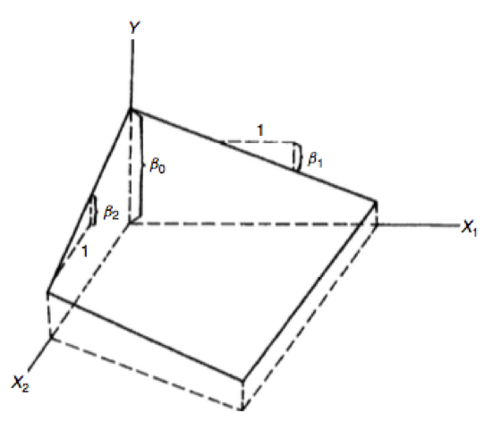

## Modelo de regressão linear múltipla geral

\[Y_i=\beta_0+\beta_1X_{i1}+\beta_2X_{i2}+\ldots + \beta_{p-1} X_{i,p-1}+\varepsilon_i\]

- \(\beta_0,\beta_1,\ldots,\beta_{p-1}\) são parâmetros.
- \(X_{i1},\ldots,X_{i,p-1}\) são constantes conhecidas.
- \(\varepsilon_i\overset{iid}{\sim}\mathcal{N}(0,\sigma^2)\).
- \(i=1,2,\ldots,n\).

Se \(X_{i0}=1\), podemos escrever:

\[Y_i=\sum_{k=0}^{p-1}\beta_kX_{ik}+\varepsilon_i\]

## Modelo de regressão linear múltipla geral

Função de regressão (hiperplano):

\[E(Y)=\beta_0+\beta_1X_1+\ldots+\beta_{p-1}X_{p-1}\]

## Regressão Linear Múltipla com notação matricial

\[Y_i=\sum_{k=0}^{p-1}\beta_kX_{ik}+\varepsilon_i\,,\quad\varepsilon_i\overset{iid}{\sim}\mathbf{N}(0,\sigma^2)\,,\quad i=1,2,\ldots,n\]

\[\mathbf{Y}_{n\times1}=\mathbf{X}_{n\times p}\boldsymbol\beta_{p\times1}+\boldsymbol\varepsilon_{n\times1}\,,\quad \boldsymbol\varepsilon\sim\mathcal{N}(\mathbf{0},\sigma^2\mathbf{I})\]

\[\mathbf{Y}_{n\times1}=\left( \begin{array}{c} Y_1\\ Y_2\\ \vdots\\ Y_n \end{array} \right) \]

\[\mathbf{X}_{n\times p}=\left( \begin{array}{ccccc} 1 & X_{11} & X_{12} & \ldots & X_{1,p-1} \\ 1 & X_{21} & X_{22} & \ldots & X_{2,p-1} \\ \vdots & \vdots & \vdots & \vdots\\ 1 & X_{n1} & X_{n2} & \ldots & X_{n,p-1} \end{array} \right)\quad \boldsymbol\beta_{p\times1}=\left( \begin{array}{c} \beta_0\\ \beta_1\\ \vdots\\ \beta_{p-1} \end{array} \right) \quad \boldsymbol\varepsilon_{n\times1}=\left( \begin{array}{c} \varepsilon_1\\ \varepsilon_2\\ \vdots\\ \varepsilon_n \end{array} \right) \]

## Regressão Linear Múltipla com notação matricial

\[E(\boldsymbol\varepsilon)_{n\times1}=\mathbf{0}_{n\times1}\]

\[Var(\boldsymbol\varepsilon)_{n\times n}=\sigma^2\mathbf{I}_{n\times n}\]

\[E(\mathbf{Y})=E(\mathbf{X}\boldsymbol\beta+\boldsymbol\varepsilon)=\mathbf{X}\boldsymbol\beta\]

\[Var(\mathbf{Y})=\sigma^2\mathbf{I}\]

## Mínimos Quadrados

Queremos encontrar \(\hat{\boldsymbol\beta}\) que minimiza:

\[\begin{eqnarray} S(\boldsymbol\beta)&=&\sum_{i=1}^n\varepsilon_i^2=\boldsymbol\varepsilon^T\boldsymbol\varepsilon=(\mathbf{Y}-\mathbf{X}\boldsymbol\beta)^T(\mathbf{Y}-\mathbf{X}\boldsymbol\beta)\\ &=& \mathbf{Y}^T\mathbf{Y}-\mathbf{Y}^T\mathbf{X}\boldsymbol\beta-\boldsymbol\beta^T\mathbf{X}^T\mathbf{Y}+\boldsymbol\beta^T\mathbf{X}^T\mathbf{X}\boldsymbol\beta\\ &=& \mathbf{Y}^T\mathbf{Y}-2\boldsymbol\beta^T\mathbf{X}^T\mathbf{Y}+\boldsymbol\beta^T\mathbf{X}^T\mathbf{X}\boldsymbol\beta \end{eqnarray}\]

\[\begin{eqnarray} \frac{\partial S(\boldsymbol\beta)}{\partial\boldsymbol\beta} = -2\mathbf{X}^T\mathbf{Y}+2\mathbf{X}^T\mathbf{X}\boldsymbol\beta \end{eqnarray}\]

Equação normal: \(\mathbf{X}^T\mathbf{X}\hat{\boldsymbol\beta}=\mathbf{X}^T\mathbf{Y}\)

\[\hat{\boldsymbol\beta}=(\mathbf{X}^T\mathbf{X})^{-1}\mathbf{X}^T\mathbf{Y}\]

## Mínimos Quadrados

\[\begin{eqnarray} Var(\hat{\boldsymbol\beta})&=&Var\left[(\mathbf{X}^T\mathbf{X})^{-1}\mathbf{X}^T\mathbf{Y}\right]\\ &=&(\mathbf{X}^T\mathbf{X})^{-1}\mathbf{X}^TVar(\mathbf{Y})\mathbf{X}(\mathbf{X}^T\mathbf{X})^{-1}\\ &=&(\mathbf{X}^T\mathbf{X})^{-1}\mathbf{X}^T\sigma^2\mathbf{I}\mathbf{X}(\mathbf{X}^T\mathbf{X})^{-1}\\ &=&\sigma^2(\mathbf{X}^T\mathbf{X})^{-1} \end{eqnarray}\]

\(\mathbf{H}\) é a matriz de projeção ortogonal no espaço coluna de \(\mathbf{X}\).

\[\hat{\mathbf{Y}}=\mathbf{X}\hat{\boldsymbol\beta}=\underbrace{\mathbf{X}(\mathbf{X}^T\mathbf{X})^{-1}\mathbf{X}^T}_{\mathbf{H}}\mathbf{Y}\]

\[\mathbf{e}=\mathbf{Y}-\hat{\mathbf{Y}}=\mathbf{Y}-\mathbf{H}\mathbf{Y}=(\mathbf{I}-\mathbf{H})\mathbf{Y}\]

## Preditores qualitativos

Muitas vezes as variáveis preditoras podem ser do tipo qualitativo:

- Sexo: feminino/masculino
- Tem ensino superior? sim/não
- etc

## Exemplo

Modelo de regressão para tempo de permanência no hospital (\(Y\)) considerando a idade (\(X_1\)) e o sexo (\(X_2\)) do paciente.

\[\begin{eqnarray} X_2 = \begin{cases} 1 & \mbox{se feminino} \\ 0 & \mbox{se masculino} \end{cases} \end{eqnarray}\]

\[Y_i=\beta_0+\beta_1X_{i1}+\beta_2X_{i2}+\varepsilon_i\]

- \(X_{i1}\) é a idade do paciente \(i\).
- \(X_{i2}\) é o sexo do paciente \(i\).

Se \(X_2=0\) (paciente masculino): \(E(Y)=\beta_0+\beta_1X_1\).

Se \(X_2=1\) (paciente feminino): \(E(Y)=(\beta_0+\beta_2)+\beta_1X_1\).

## Preditores qualitativos

Em geral, representamos uma variável qualitativa com \(c\) classes através de \(c-1\) variáveis indicadoras.

Por exemplo, se temos uma variável qualitativa do estado de incapacidade do paciente com as seguintes classes: incapaz, parcialmente incapaz, não incapaz. Utilizamos as seguinte vairáveis indicadoras:

\[\begin{eqnarray} X_3 = \begin{cases} 1 & \mbox{se não incapaz} \\ 0 & \mbox{caso contrário} \end{cases} \end{eqnarray}\]

\[\begin{eqnarray} X_4 = \begin{cases} 1 & \mbox{se parcialmente incapaz} \\ 0 & \mbox{caso contrário} \end{cases} \end{eqnarray}\]

\[Y_i=\beta_0+\beta_1X_{i1}+\beta_2X_{i2}+\beta_3X_{i3}+\beta_4X_{i4}+\varepsilon_i\]

## Exemplo: conjunto de dados `swiss`

`require(datasets); data(swiss); ?swiss`

A data frame with 47 observations on 6 variables, each of which is in percent, i.e., in [0, 100].

[,1] Fertility Ig, ‘common standardized fertility measure’

[,2] Agriculture % of males involved in agriculture as occupation

[,3] Examination % draftees receiving highest mark on army examination

[,4] Education % education beyond primary school for draftees.

[,5] Catholic % ‘catholic’ (as opposed to ‘protestant’).

[,6] Infant.Mortality live births who live less than 1 year.

All variables but ‘Fertility’ give proportions of the population.

## Exemplo: conjunto de dados `swiss`

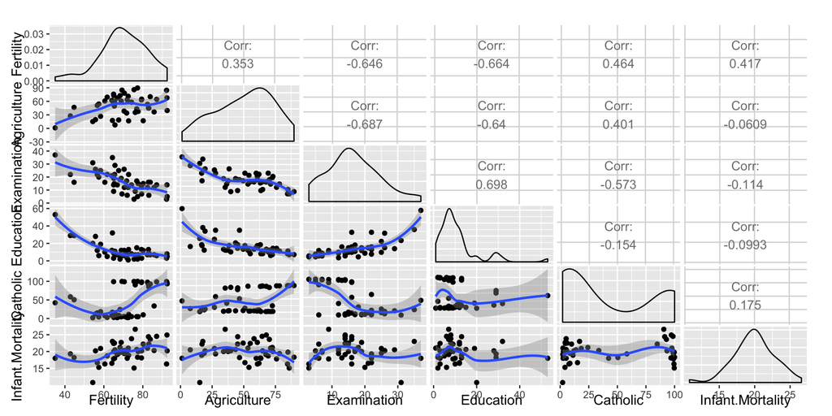

## Exemplo: conjunto de dados `swiss`

```r
modelo <- lm(Fertility ~ . , data = swiss)
summary(modelo)$coefficients
```

```
##                    Estimate  Std. Error   t value     Pr(>|t|)
## (Intercept)      66.9151817 10.70603759  6.250229 1.906051e-07
## Agriculture      -0.1721140  0.07030392 -2.448142 1.872715e-02
## Examination      -0.2580082  0.25387820 -1.016268 3.154617e-01
## Education        -0.8709401  0.18302860 -4.758492 2.430605e-05
## Catholic          0.1041153  0.03525785  2.952969 5.190079e-03
## Infant.Mortality  1.0770481  0.38171965  2.821568 7.335715e-03
```

## Exemplo: conjunto de dados `swiss`

- `Agriculture`: expressa em porcentagem (0 - 100)
- Estimativa é -0.172114.
- Segundo o modelo, espera-se um decréscimo de 0.17 na fertilidade para cada 1% de aumento de pessoas do sexo masculino envolvidas na agricultura, mantendo as demais variáveis fixas.
- O teste-t para \(H_0: \beta_{Agri} = 0\) versus \(H_a: \beta_{Agri} \neq 0\) é significante.
- A título de curiosidade, a estimativa do efeito de agricultura, sem ajustar pelas demais variáveis é:

```
##               Estimate Std. Error   t value     Pr(>|t|)
## (Intercept) 60.3043752 4.25125562 14.185074 3.216304e-18
## Agriculture  0.1942017 0.07671176  2.531577 1.491720e-02
```

([Paradoxo de Simpson](https://en.wikipedia.org/wiki/Simpson%27s_paradox))

## Simulação

Ao considerarmos outras variáveis no modelo, o sinal do efeito de uma dada variável pode inverter. Vamos simular um caso para exemplificar.

- Simulamos 100 v.a. com relação linear: \(Y\), \(X_1\) e \(X_2\).
- \(X_1\) tem relação linear com \(X_2\).
- \(X_1\) tem um efeito ajustado negativo sobre \(Y\).
- \(X_2\) tem um efeito ajustado positivo sobre \(Y\).

## Simulação

```r
n <- 100
x2 <- 1 : n
x1 <- .01 * x2 + runif(n, -.1, .1)
y = -x1 + x2 + rnorm(n, sd = .01)
summary(lm(y ~ x1))$coef
```

```
##              Estimate Std. Error   t value     Pr(>|t|)
## (Intercept)  3.949246   1.097604  3.598062 5.046871e-04
## x1          92.855725   1.890839 49.108203 7.998659e-71
```

```r
summary(lm(y ~ x1 + x2))$coef
```

```
##                Estimate   Std. Error    t value      Pr(>|t|)
## (Intercept) -0.00226433 0.0021338254   -1.06116  2.912523e-01
## x1          -0.97784868 0.0176587887  -55.37462  3.276105e-75
## x2           0.99980104 0.0001845196 5418.39917 1.203119e-267
```

## Simulação

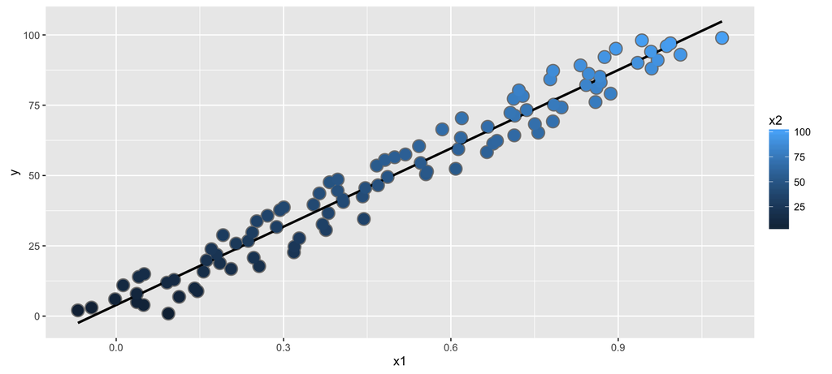

\(Y\) e \(X_1\) têm relação positiva (não ajustada). Note que \(X_2\) também aumenta com \(Y\).

## Simulação

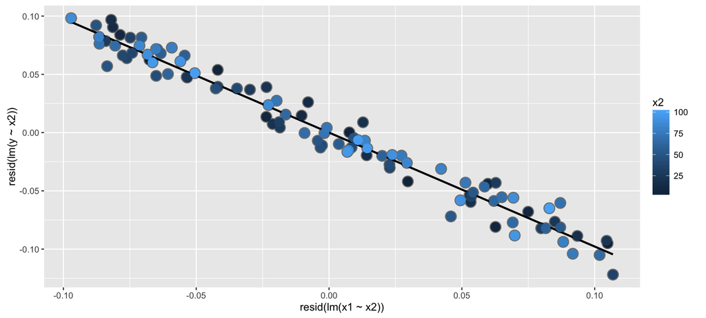

Ajustando \(X_1\) e \(Y\) através do resíduo da regressão de cada uma em \(X_2\) temos a relação correta entre \(X_1\) e \(Y\).

## Exemplo: conjunto de dados `swiss`

Vamos considerar a seguinte variável qualitativa:

```r
library(dplyr);
swiss = mutate(swiss, CatholicBin = 1 * (Catholic > 50))
```

## Exemplo: conjunto de dados `swiss`

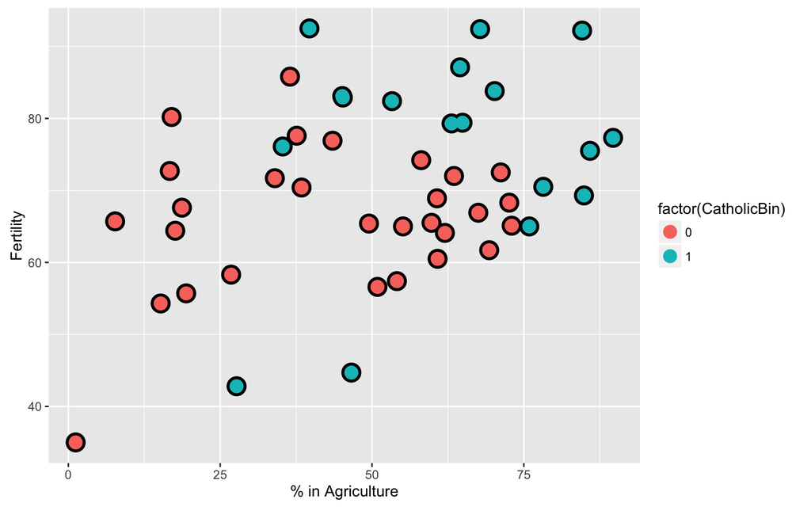

## Exemplo: conjunto de dados `swiss`

\[Y_i=\beta_0+\beta_1X_{i1}+\beta_2X_{i2}+\varepsilon_i\]

- \(Y_i\): `Fertility`
- \(X_{i1}\): `Agriculture`
- \(X_{i2}\): `CatholicBin`

## Exemplo: conjunto de dados `swiss`

Sem considerar \(X_{i2}\):

```r
summary(lm(Fertility ~ Agriculture, data = swiss))$coef
```

```
##               Estimate Std. Error   t value     Pr(>|t|)
## (Intercept) 60.3043752 4.25125562 14.185074 3.216304e-18
## Agriculture  0.1942017 0.07671176  2.531577 1.491720e-02
```

Este modelo assume que ajustamos apenas uma reta.

## Exemplo: conjunto de dados `swiss`

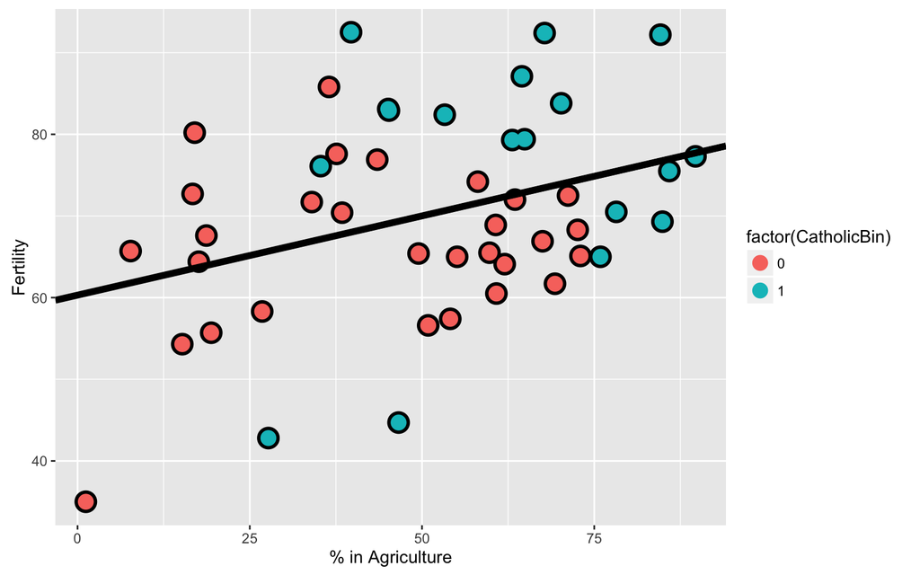

## Exemplo: conjunto de dados `swiss`

No modelo:

\[Y_i=\beta_0+\beta_1X_{i1}+\beta_2X_{i2}+\varepsilon_i\]

Temos que, se \(X_{i2}=0\):

\[Y_i=\beta_0+\beta_1X_{i1}+\varepsilon_i\]

e se \(X_{i2}=1\):

\[Y_i=(\beta_0+\beta_2)+\beta_1X_{i1}+\varepsilon_i\]

Ou seja, temos duas retas paralelas ajustadas (uma para cada categoria de `CatholicBin`).

## Exemplo: conjunto de dados `swiss`

```r
summary(lm(Fertility ~ Agriculture + factor(CatholicBin), data = swiss))$coef
```

```
##                        Estimate Std. Error   t value     Pr(>|t|)
## (Intercept)          60.8322366  4.1058630 14.815944 1.032493e-18
## Agriculture           0.1241776  0.0810977  1.531210 1.328763e-01
## factor(CatholicBin)1  7.8843292  3.7483622  2.103406 4.118221e-02
```

Segundo o modelo, 7.88 é a mudança esperada no intercepto da relação linear entre agricultura e fertilidade quando comparamos não-católicos a católicos.

## Exemplo: conjunto de dados `swiss`

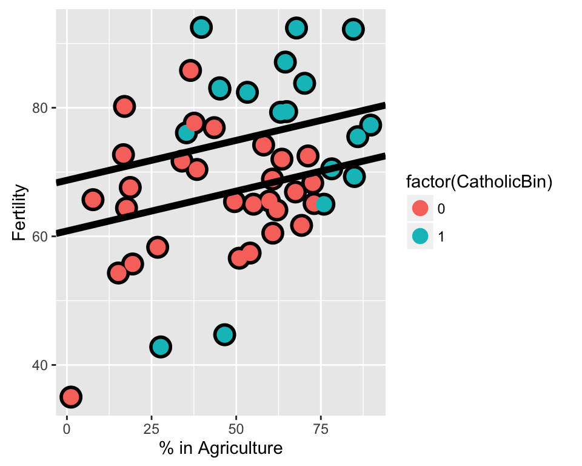

## Exemplo: conjunto de dados `swiss`

Podemos também considerar um modelo que permite diferentes interceptos e diferentes coeficientes angulares (retas não paralelas). Isto é obtido considerando termo de **interação**.

\[Y_i=\beta_0+\beta_1X_{i1}+\beta_2X_{i2}+\beta_3X_{i1}X_{i2}+\varepsilon_i\]

Agora, quando \(X_{i2}=0\):

\[Y_i=\beta_0+\beta_1X_{i1}+\varepsilon_i\]

e quando \(X_{i2}=1\):

\[Y_i=(\beta_0+\beta_2)+(\beta_1+\beta_3)X_{i1}+\varepsilon_i\]

## Exemplo: conjunto de dados `swiss`

```r
summary(lm(Fertility ~ Agriculture * factor(CatholicBin), data = swiss))$coef
```

```
##                                     Estimate  Std. Error    t value
## (Intercept)                      62.04993019  4.78915566 12.9563402
## Agriculture                       0.09611572  0.09881204  0.9727127
## factor(CatholicBin)1              2.85770359 10.62644275  0.2689238
## Agriculture:factor(CatholicBin)1  0.08913512  0.17610660  0.5061430
##                                      Pr(>|t|)
## (Intercept)                      1.919379e-16
## Agriculture                      3.361364e-01
## factor(CatholicBin)1             7.892745e-01
## Agriculture:factor(CatholicBin)1 6.153416e-01
```

## Exemplo: conjunto de dados `swiss`

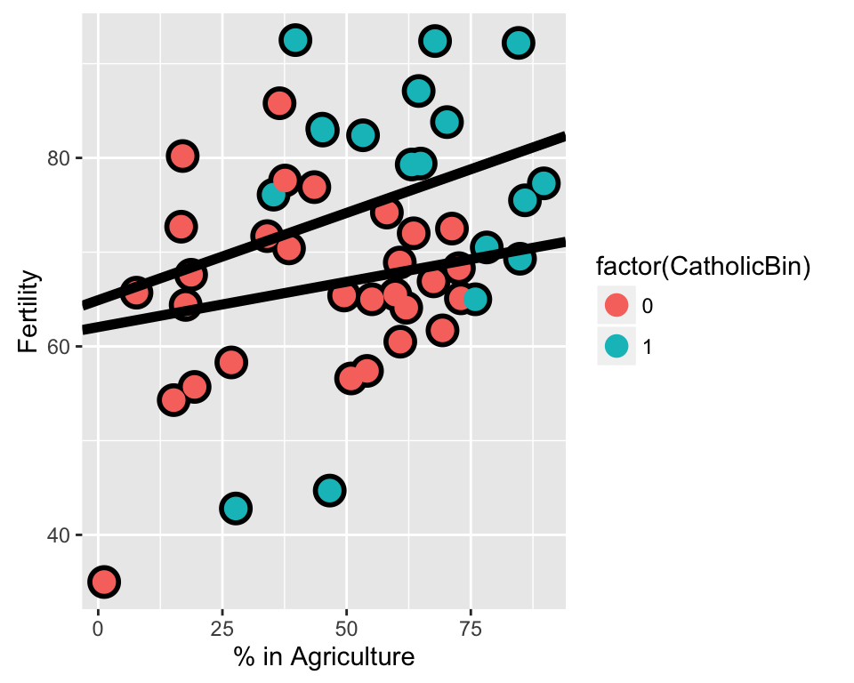

## Exemplo: conjunto de dados `swiss`

Segundo o modelo ajustado, 2.8577 é a mudança esperada estimada no intercepto da reta de relação entre `Agriculture` e `Fertility` quando comparamos não católicos a católicos.

O intercepto estimado entre os não-católicos é 62.04993 e o intercepto estimado entre os católicos é 62.04993 + 2.85770.

## Formas Quadráticas

\[\mathbf{Y}^T\mathbf{A}\mathbf{Y}=\sum_i\sum_ja_{ij}Y_iY_j\quad\quad a_{ij}=a_{ji}\]

Exemplos:

\[SQT=\mathbf{Y}^T\left[ \mathbf{I}-\frac{1}{n}\mathbf{1}\mathbf{1}^T \right]\mathbf{Y}\]

\[ SQE=\mathbf{Y}^T(\mathbf{I}-\mathbf{H})\mathbf{Y} \]

\[SQReg=\mathbf{Y}^T\left[ \mathbf{H}-\frac{1}{n}\mathbf{1}\mathbf{1}^T \right]\mathbf{Y}\]

## Teorema de Cochran

Seja \(X_i\overset{iid}{\sim}\mathcal{N}(0,\sigma^2)\) e suponha que

\[\sum_{i=1}^nX_i^2=Q_1+Q_2+\ldots+Q_k\]

em que

\[Q_i=\mathbf{X}^T\mathbf{A}_i\mathbf{X}\]

\(rank(A_i)=r_i\) e \(r_1+r_2+\ldots r_k=n\). Então temos que:

- \(Q_1,Q_2,\ldots,Q_k\) são independentes
- \(Q_i\sim\sigma^2\chi^2(r_i)\), \(i=1,2,\ldots,k\).

## ANOVA: Regressão Linear Múltipla

| Fonte de Variação | gl | SQ | QM |
| --- | --- | --- | --- |
| Regressão | \(p-1\) | \(SQReg=\mathbf{Y}^T\left[ \mathbf{H}-\frac{1}{n}\mathbf{1}\mathbf{1}^T \right]\mathbf{Y}\) | \(SQReg/(p-1)\) |
| Erro | \(n-p\) | \(SQE=\mathbf{Y}^T(\mathbf{I}-\mathbf{H})\mathbf{Y}\) | \(SQE/(n-p)\) |
| Total (ajustada) | \(n-1\) | \(\mathbf{Y}^T\left[ \mathbf{I}-\frac{1}{n}\mathbf{1}\mathbf{1}^T \right]\mathbf{Y}\) |  |

## Teste \(F\)

- \(H_0\): \(\beta_1=\beta_2=\ldots=\beta_{p-1}=0\).
- \(H_1\): pelo menos um \(\beta_k\neq0\), \(k=1,2,\ldots,p-1\).

Estatística do teste:

\[F^*=\frac{SQReg/(p-1)}{SQE/(n-p)}\overset{\mbox{sob $H_0$}}{\sim}F_{p-1,n-p}\]

## Intervalo de Confiança para \(\beta_k\)

Um intervalo de \(100(1-\alpha)\%\) de confiança para \(\beta_k\) é dado por:

\[\begin{eqnarray} IC(\beta_k, 1-\alpha) &=& \left[\hat{\beta}_k -t_{n-p,\alpha/2}\sqrt{\widehat{Var(\hat{\beta}_k)}};\right.\\ & &\left. \hat{\beta}_k +t_{n-p,\alpha/2}\sqrt{\widehat{Var(\hat{\beta}_k)}}\right] \end{eqnarray}\]

## Teste de hipótese para \(\beta_k\)

- \(H_0\): \(\beta_k=0\).
- \(H_1\): \(\beta_k\neq0\).

Estatística do teste:

\[t^*=\frac{\hat{\beta}_k}{\sqrt{\widehat{Var(\hat{\beta}_k)}}}\overset{\mbox{sob $H_0$}}{\sim}t_{n-p}\]

## Leitura

- Applied Linear Statistical Models: Capítulo 6.
- Weisberg - Applied Linear Regression: Capítulos 3, 4 e seção 5.1.
- Faraway - [Linear Models with R](http://www.maths.bath.ac.uk/~jjf23/LMR/): Capítulo 5.
- Caffo - [Regression Models for Data Science in R](https://leanpub.com/regmods): Multivariable regression analysis, Multivariable examples and tricks.

[figure not shown]